# The Bootstrap Method :)

Joaco Alvarez Gal

June 2022

Abstract

We make a guided implementation of one of the fanciest methods in Statistics. It’s like magic.

# The context of what we are doing to do

The purpose is to illustrate the Bootstrap through an example. This is a very powerful and useful technique with many applications. In order to develop the idea behind the method, we are going to make use of a motivation presented in the ISLR book.

Suppose we want to invest in two different stocks in the market. We have access to historical data of the daily returns (joint returns) of those two assets, $(X_i,Y_i) \stackrel{i.i.d.}{\sim} \mathbb{P}_{X,Y},\quad i=1,\dots,n$. $\mathbb{P}_{X,Y}$ denotes a joint probability distribution. For simplicity we assume these observations are independent, however, we could make more relaxed assumptions (or use a more sophisticated Time Series Model) and Bootstrap still provides the magic. We are going to allocate a proportion of $\alpha\in (0,1)$ of our total money we want to invest to the stock X and the rest ($1-\alpha$) to asset Y. We want to make the allocation in such a way that we minimize the variance of the return of the portfolio.

In this context, the total return in terms of the proportion we invest to each asset is given by $f(\alpha, X, Y):= \alpha X+(1-\alpha)Y, \quad \forall \alpha \in (0,1)$ , where $(X,Y) \sim \mathbb{P}_{X,Y}$ is an observation of the daily joint returns of the asset. We want to minimize $\mathbb{V}ar(f(\alpha, X, Y))$ with respect to alpha, picking the $\alpha \in (0,1)$ that minimizes that expression. That is, we want to minimize the variance of the daily return of a portfolio consisting of two assets, with daily returns for each asset denoted by X and Y, respectively. We use the following notation: $\sigma_X^2 \mathrel{:=}\mathbb{V}(X),\quad \sigma_Y^2:=\mathbb{V}ar(Y), \quad \sigma_{X,Y}:=Cov(X,Y)$. We assume that we know this quantities, and we assume that they exist.

Notice that $\mathbb{V}ar(f(\alpha, X, Y))=\mathbb{V}(\alpha X+(1-\alpha)Y)= \alpha^2\mathbb{V}(X)+(1-\alpha)^2\mathbb{V}(Y)+2\alpha(1-\alpha)Cov(X,Y)= \alpha^2\sigma_X^2+(1-\alpha)^2\sigma_Y^2+2\alpha(1-\alpha)\sigma_{X,Y}$ is a polynomial in $\alpha$. We can use simple calculus to verify that
$$\alpha^*:=\frac{\sigma_Y^2-\sigma_{X,Y}}{\sigma_X^2+\sigma_Y^2-2\sigma_{X,Y}}$$
is a global minimum of $F(\alpha):=\mathbb{V}ar(f(\alpha, X, Y))$. Now, given that $\sigma_X^2, \sigma_Y^2$ and $\sigma_{X,Y}$ are unknown quantities, we can construct a estimator of $\alpha^*$, denoted by $\widehat{\alpha^*}$, using the data and the unbiased estimators of $\sigma_X^2, \sigma_Y^2$ and $\sigma_{X,Y}$, denoted by $\widehat{\sigma_X^2}, \widehat{\sigma_Y^2}, \widehat{\sigma_{X,Y}}$ and get:

$$\widehat{\alpha^*}\mathrel{:=}\frac{\widehat{\sigma_Y^2}-\widehat{\sigma_{X,Y}}}{\widehat{\sigma_X^2}+\widehat{\sigma_Y^2}-2\widehat{\sigma_{X,Y}}}$$
Our objective is to know (or in statistical terms, to estimate) $\alpha^*$, and we are going to do that through $\widehat{\alpha^*}$ and the available data.

# Theory: we have access to a data generator

We first generate some data.

```r
alphas=rep(0,1000)# to store the data
set.seed(1)
mu=c(0.3,0.9) #average daily returns
Sigma=matrix(c(2,-2,-2,4), nrow=2,  byrow = T) #positive definite matrix
mu
```

```
## [1] 0.3 0.9
```

```r
Sigma
```

```
##      [,1] [,2]
## [1,]    2   -2
## [2,]   -2    4
```

```r
library(MASS)
returns=mvrnorm(n = 100, mu, Sigma)
```

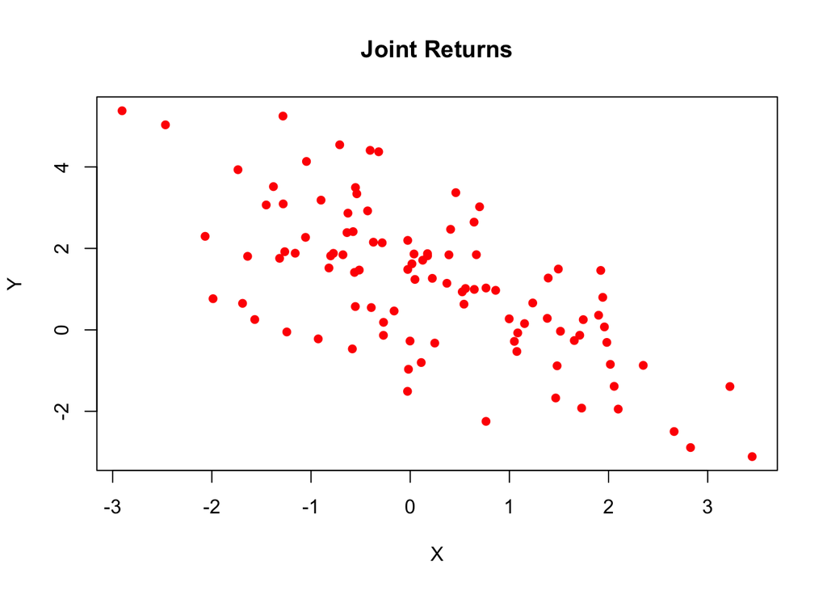

```r
plot(returns, xlab = 'X',ylab='Y', main='Joint Returns', col='red', pch=16)
```

```r
#the scatter plot of the data  suggests a mean near (0.3,0.9), the center of the elipse
# and a negative correlation between the variables, since the principal axis of the elipse
#has a negative slope.
```

```r
?var
#we generate 1000 iid observations of an estimator of alpha
for(j in 1:1000){
  set.seed(j) # to conserve reproducibility of our results
  returns=mvrnorm(n = 100, mu, Sigma) #we generate a random sample
  sigx=var(returns[,1])
  sigy=var(returns[,2])
  covxy=cov(returns[,1],returns[,2])
  alpha=(sigy-covxy)/(sigx+sigy-2*covxy)
  alphas[j]=alpha

}
alphas
```

By the definition of $\alpha^*$, the exact optimal alpha is

```r
(4+2)/(4+2+4)
```

```
## [1] 0.6
```

This means that the portfolio with minimal variance allocates .6 of the available cash to X and .4 to Y, which somehow makes sense to allocate a greater proportion to $X$ since $X$ has less variance. Compare that to a point estimate of $\alpha^*$

```r
(alphaEst=mean(alphas))
```

```
## [1] 0.5997652
```

Niceee! This is very close to the real value of $\alpha^*$

We can generate a histogram of the simulated estimates of $\alpha^*$, which helps us get a sense of the distribution of $\widehat\alpha^*$

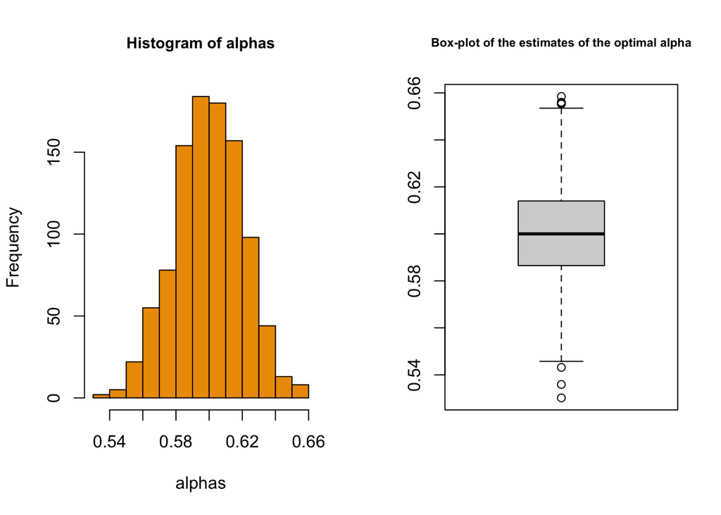

```r
par(mfrow=c(1,2))
hist(alphas, col='orange2', cex.main=.9)
boxplot(alphas, main='Box-plot of the estimates of the optimal alpha',cex.main=.7)
```

However, in order to properly assess the quality of the estimator, we need to consider the uncertainty associated to a point estimation. Don’t forget (EVER!) to associate some quantification of uncertainty to your estimator (Henri Luigi Grandson Decks).

```r
alphaVar=var(alphas)
```

Formally, we would construct a confidence interval, making some assumptions or appealing to asymptotic results. In order to gain some intuition, we will just appeal to an informal rule of thumb. That being said, we would usually expect 95% of the observations (assuming normality of $\hat{\alpha^*}$) of our estimations of $\alpha^*$ to live in

```r
c(alphaEst-2*sqrt(alphaVar), alphaEst+2*sqrt(alphaVar))
```

```
## [1] 0.5588012 0.6407292
```

which is an interval with small length and contains the value $\alpha^*=0.6$, hence the estimator is one of good quality.

# Reality: we have finite data (Bootstrap)

We now assume that we only have a sample of n=100 daily returns.

```r
set.seed(1)
returns=mvrnorm(n = 100, mu, Sigma)
sigx=var(returns[,1])
sigy=var(returns[,2])
covxy=cov(returns[,1],returns[,2])
alpha=(sigy-covxy)/(sigx+sigy-2*covxy)
alpha #is our point estimate  of alpha
```

```
## [1] 0.5977546
```

We would like to associate an uncertainty to that point estimation just as we did with the theoretical case. This is when Bootstrap comes in We will apply $B=1,000$ Bootstrap samples.

```r
?sample
set.seed(1)
#we make use of the sample function
sample(1:10, size=4, replace = TRUE, prob = NULL)
```

```
## [1] 9 4 7 1
```

```r
sample(1:10, size=10, replace = TRUE, prob = NULL)
```

```
##  [1]  2  7  2  3  1  5  5 10  6 10
```

```r
#that is to gain  some intuition with the sample function
#we generate 1000 Bootstrap samples of alpha
alphasBoot=1:1000 # a vector to store the simulated samples
for(k in 1:1000){
  set.seed(k) #in order to have reproducibility
  # we generate a random sample based on the indices of the data
  samp=sample(1:100, size=100, replace = TRUE, prob = NULL)
  BootSamp=as.data.frame(matrix(nrow=100,ncol=2)) #now we extract the observations associated
  #to those indices
  for(q in 1:100){
    BootSamp[q,1]=returns[samp[q],1]
    BootSamp[q,2]=returns[samp[q],2]
  }
  sigxx=var(BootSamp[,1])
  sigyy=var(BootSamp[,2])
  covxy=cov(BootSamp[,1], BootSamp[,2])
  alphasBoot[k]=(sigyy-covxy)/(sigxx+sigyy-2*covxy)
}
```

We can now estimate the variance of the estimator using the Bootstrap samples

```r
var(alphasBoot)
```

```
## [1] 0.0003518312
```

With the data generator we obtained a very close estimation to the variance

```r
var(alphas)
```

```
## [1] 0.0004195125
```

We can visualize the observations of the alphas that we obtained through Bootstrap re-sampling.

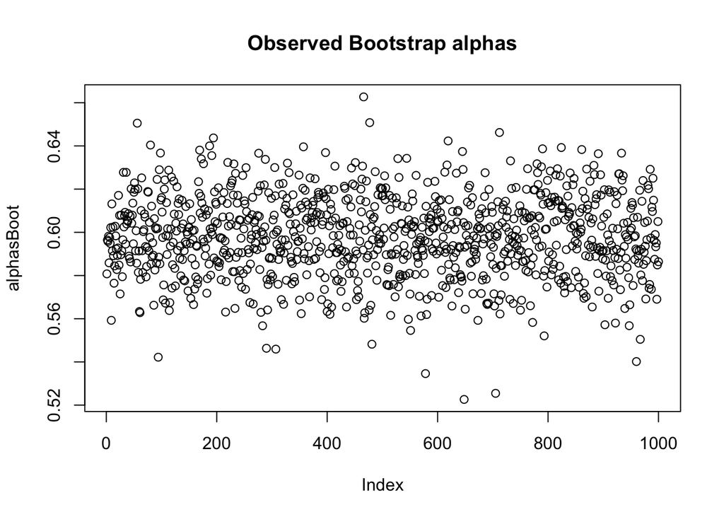

```r
plot(alphasBoot, main='Observed Bootstrap alphas')
```

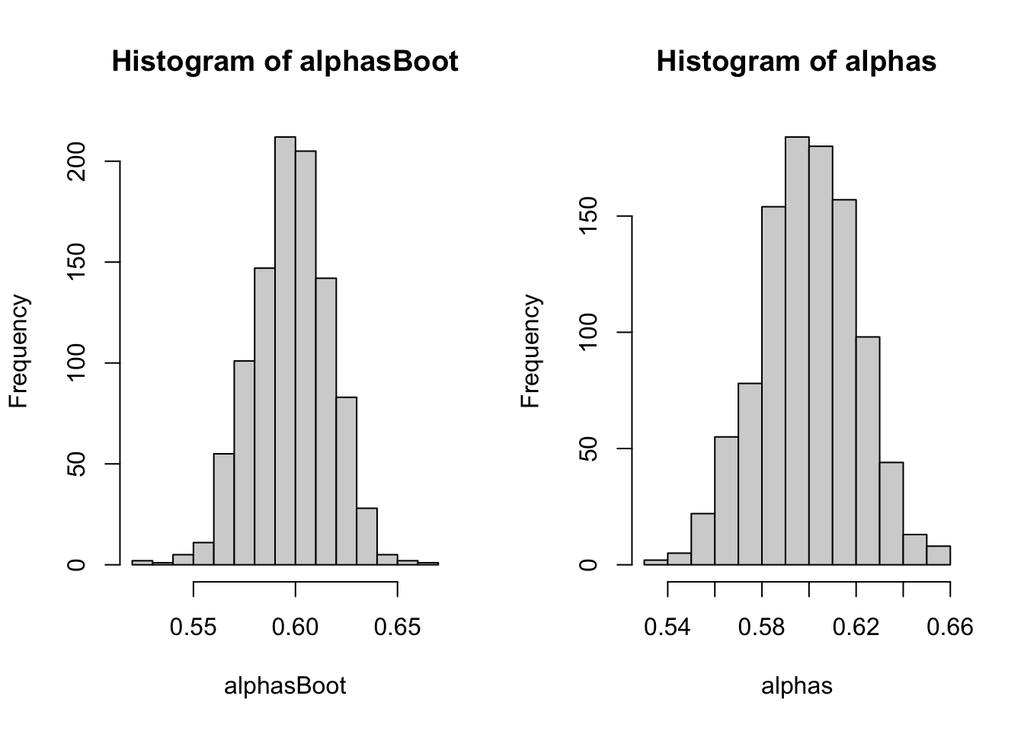

```r
par(mfrow=c(1,2))
hist(alphasBoot)
hist(alphas)
```

Oleee! They look impressively similar! They look VERY similar! And this is the magic of the Bootstrap method: we are getting the distribution of the estimator of $\alpha^*$ without a ridiculously big sample, only by applying computational power to an available data.

# Some plots using ggplot

```r
library(ggplot2)
```

In order to use ggplot, the data must be a data frame!

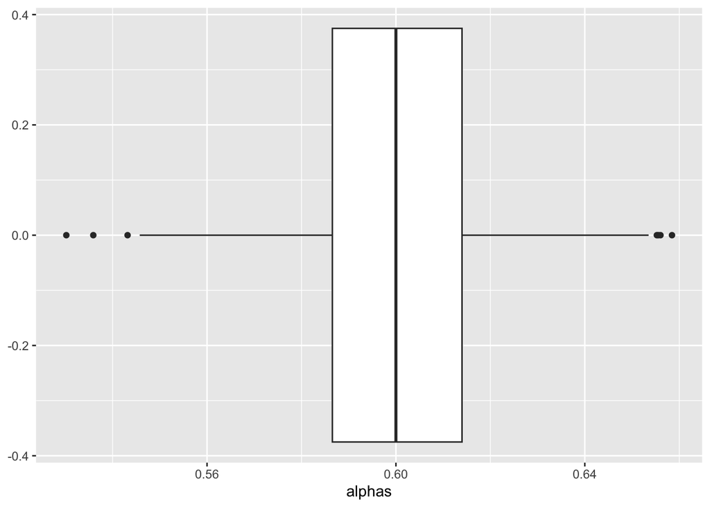

```r
ggplot(data=as.data.frame(alphas), aes(x=alphas))+
  geom_boxplot()
```

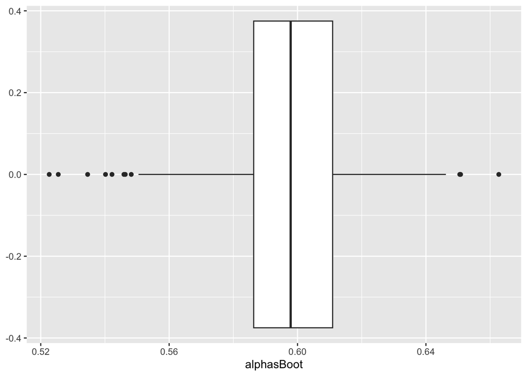

```r
ggplot(data=as.data.frame(alphasBoot), aes(x=alphasBoot))+
  geom_boxplot()
```

We can compare the two box-plots and see that, despite some differences, whey look quite the same.

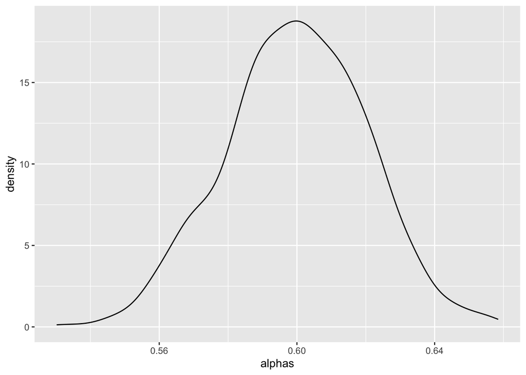

```r
ggplot(data=as.data.frame(alphas), aes(x=alphas))+
  geom_density()
```

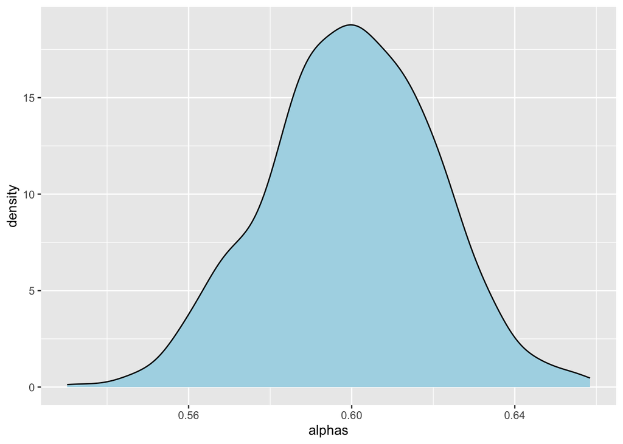

```r
ggplot(data=as.data.frame(alphas), aes(x=alphas))+
  geom_density(fill='lightblue')
```

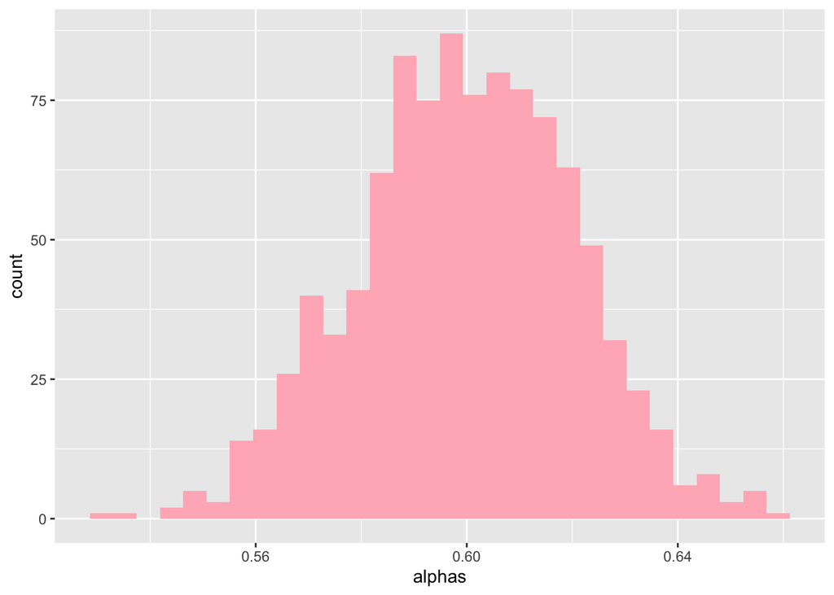

```r
ggplot(data=as.data.frame(alphas), aes(x=alphas))+
  geom_histogram(fill='lightpink')
```

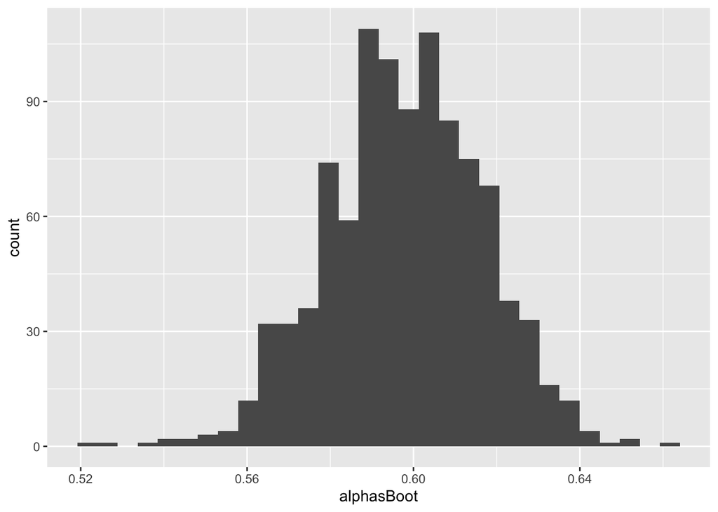

```r
p1=ggplot(data=as.data.frame(alphasBoot), aes(x=alphasBoot))+
  geom_histogram()

p2=ggplot(data=as.data.frame(alphas), aes(x=alphas))+
  geom_histogram(color="green4", fill="green4")
p1
```

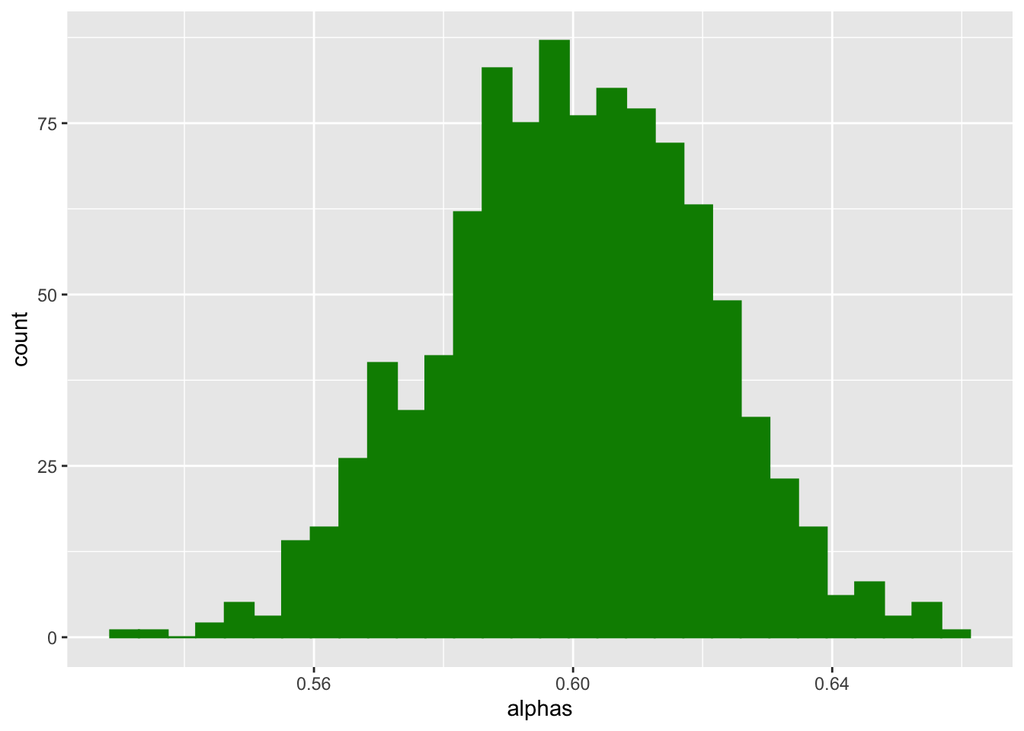

```r
p2
```

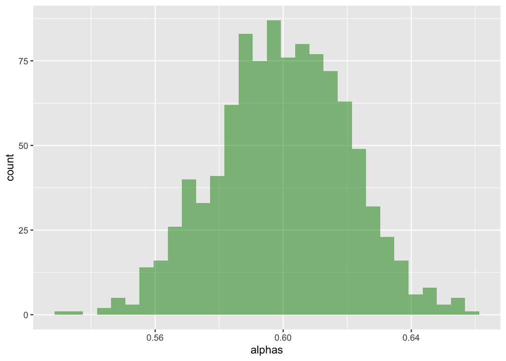

```r
ggplot(data=as.data.frame(alphas), aes(x=alphas))+
  geom_histogram( fill="green4", alpha=.5)
```

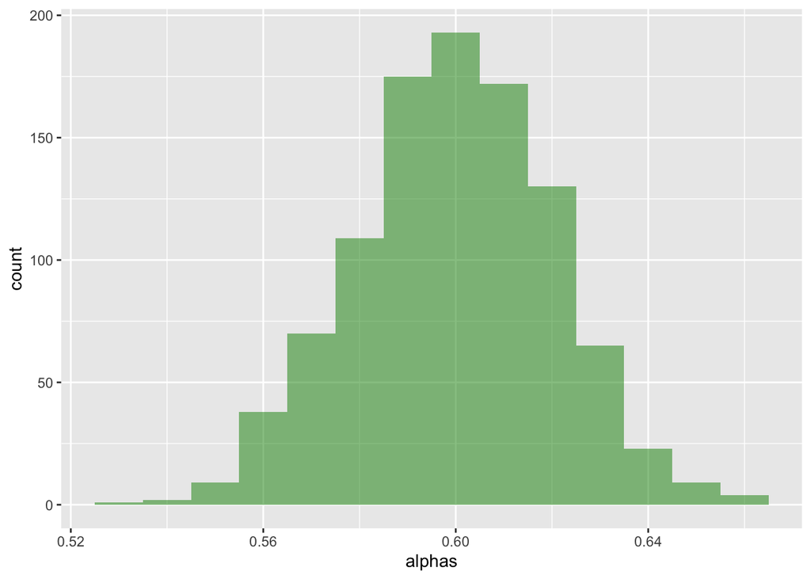

```r
ggplot(data=as.data.frame(alphas), aes(x=alphas))+
  geom_histogram( fill="green4", alpha=.5, binwidth=.01)
```

```r
df=data.frame(name=c(rep('alphas',1000), rep('alphasBoot',1000)), value=c(alphas, alphasBoot))

df
```

Violin plot

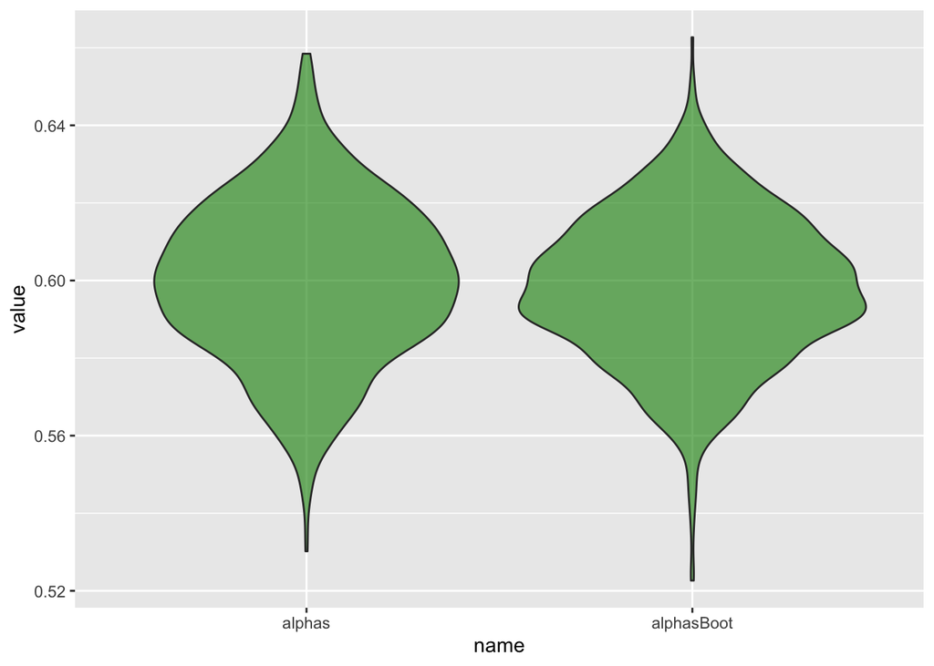

```r
ggplot(data=df, aes(x=name, y=value), fill=name)+
  geom_violin(fill='green4', alpha=.6)
```

The densities look very very similar :) Thus, applying the Bootstrap is quite useful in this example!